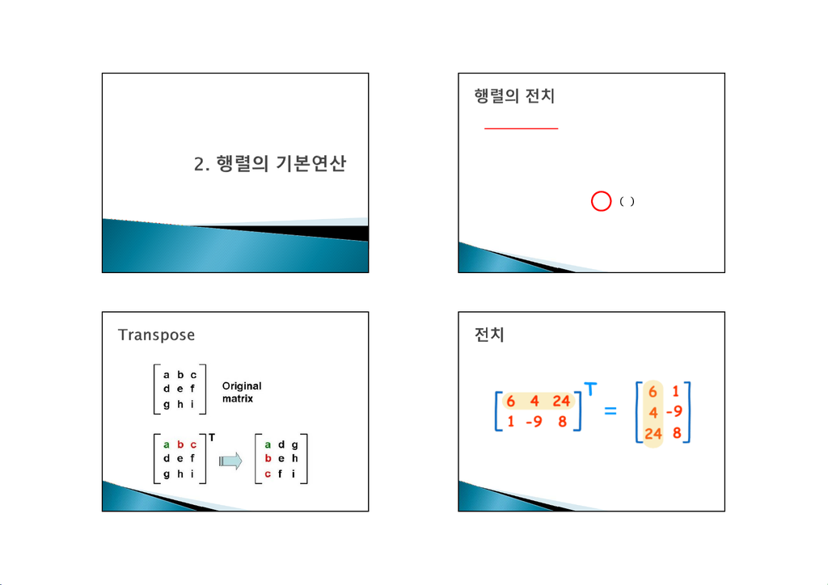

2021-08-11

1

행렬대수학 (이영경)1

전치(transpose)

: 한 행렬의 행과 열의 원소를 바꾸는 연산.

표현.

2

행렬대수학 (이영경)

3

행렬대수학 (이영경)4

행렬대수학 (이영경)

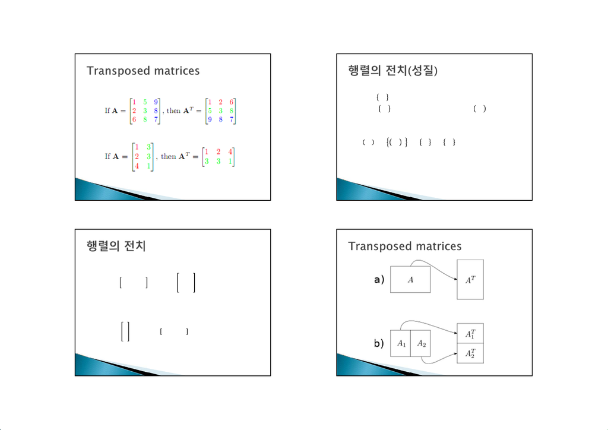

2021-08-11

2

5

행렬대수학 (이영경)

◦반사성 연산(reflexive operation)

𝑨

 𝑎

◦벡터

행벡터의 전치는 열벡터! 열벡터의 전치는 행벡터

6

행렬대수학 (이영경)

예.

⇒ 𝑨

14

25

36

, 𝑎

𝒙

1

2

3

⇒ 𝒙

7

행렬대수학 (이영경)8

행렬대수학 (이영경)

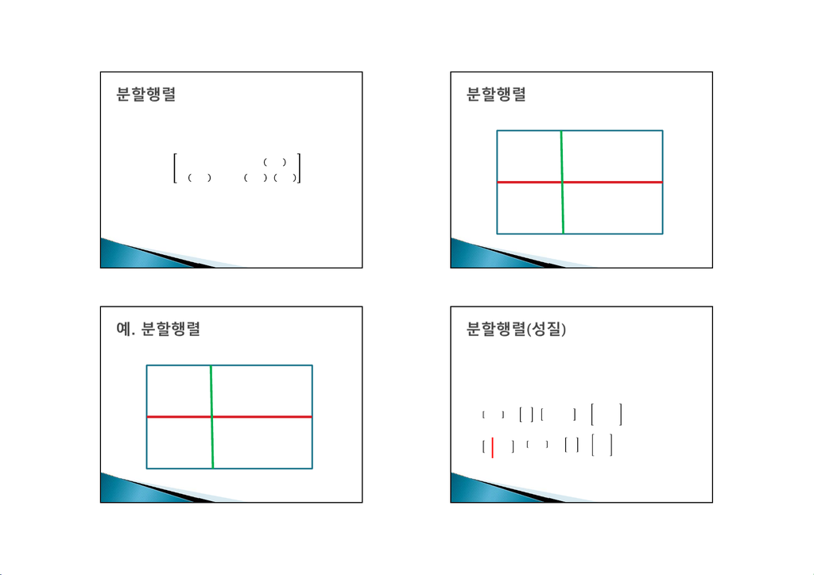

2021-08-11

3

여기서, 𝑲, 𝑳, 𝑴, 𝑵을행렬 𝑨의 분할 행렬이라 한다.

9

행렬대수학 (이영경)행렬대수학 (이영경)10

𝑨

𝑲𝑳

𝑴𝑵

행렬대수학 (이영경)11

𝑨

𝑲𝑳

𝑴𝑵

◦같은 행(열)에 위치한 부분 행렬들의 행(열)의 차원은 다 같아야 하고,

부분행렬들의 열(행)의 합은 본 행렬의 열(행)의 수와 같아야 한다.

◦분할행렬의 전치

 𝑿

𝑫𝑬𝑭

𝑨𝑫

𝑩𝑬

𝑪𝑭

12

행렬대수학 (이영경)

𝑿

𝒀

23

87

94

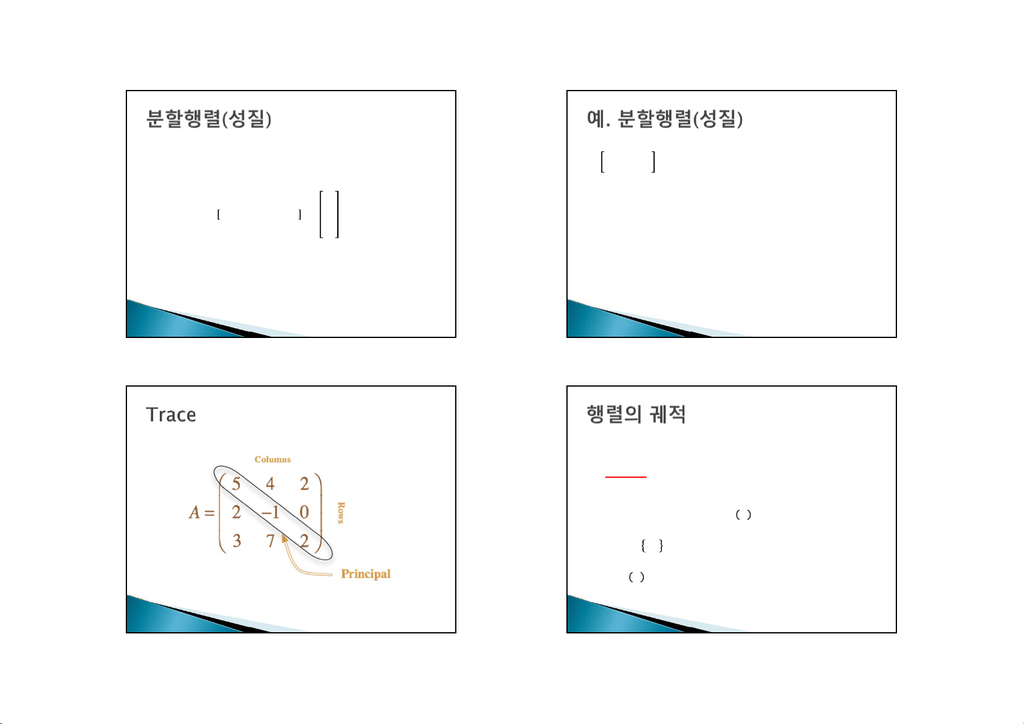

2021-08-11

4

◦행렬을 벡터들로 분할

𝒃

𝒃

⋮

𝒃

단, 𝒂는 열벡터, 𝒃는 행벡터

13

행렬대수학 (이영경)

374

행렬대수학 (이영경)14

15

행렬대수학 (이영경)

diagonal

궤적(trace)

:정방행렬의 대각원소들의 합

표현.

행렬 𝑨의 트레이스는 𝑡𝑟 𝑨로표현

16

행렬대수학 (이영경)

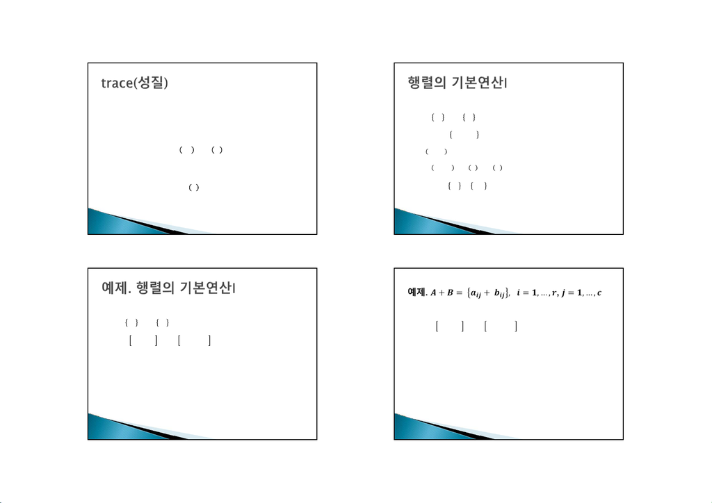

2021-08-11

5

◦정방행렬에 대해서만 트레이스를 정의

◦전치행렬의 트레이스는 그 행렬의 트레이스와 같다.

◦스칼라의 트레이스는 자기 자신이 트레이스

17

행렬대수학 (이영경)

(차원이 같은 행렬끼리 가능한 연산)

𝑩

18

행렬대수학 (이영경)

(차원이 같은 행렬끼리 가능한 연산)

𝑨 𝑎 , 𝑩 𝑏 , 𝑖1,…,𝑟, 𝑗1,…,𝑐, 𝜆 ∈ 𝑅

, 𝑩 101

, 𝝀2일때,

19

행렬대수학 (이영경)

(차원이 같은 행렬끼리 가능한 연산)

343

, 𝑩 101

20

행렬대수학 (이영경)

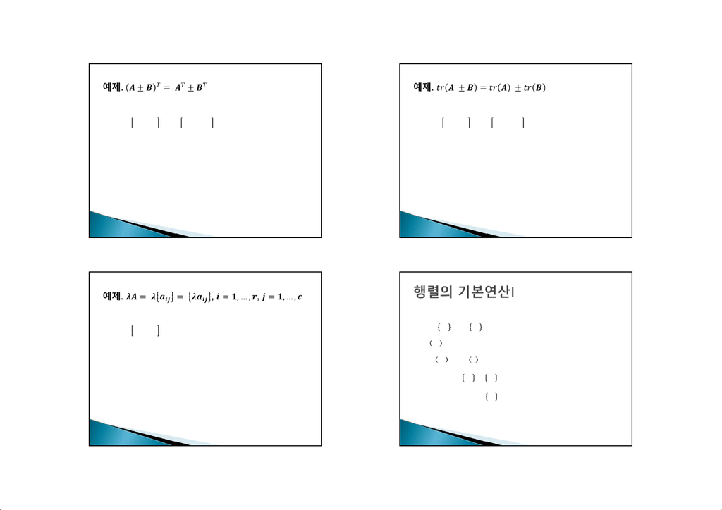

2021-08-11

6

(차원이 같은 행렬끼리 가능한 연산)

343

, 𝑩 101

31 4일때,

21

행렬대수학 (이영경)

(차원이 같은 행렬끼리 가능한 연산)

343

, 𝑩 101

31 4일때,

22

행렬대수학 (이영경)

(차원이 같은 행렬끼리 가능한 연산)

343

, 𝝀2일때,

23

행렬대수학 (이영경)

(차원이 같은 행렬에서만 가능한 연산)

𝑨 𝑎 , 𝑩 𝑏 , 𝑖1,…,𝑟, 𝑗1,…,𝑐, 𝜆 ∈ 𝑅

◦𝑡𝑟 𝜆𝑨  𝜆 𝑡𝑟 𝑨

24

행렬대수학 (이영경)

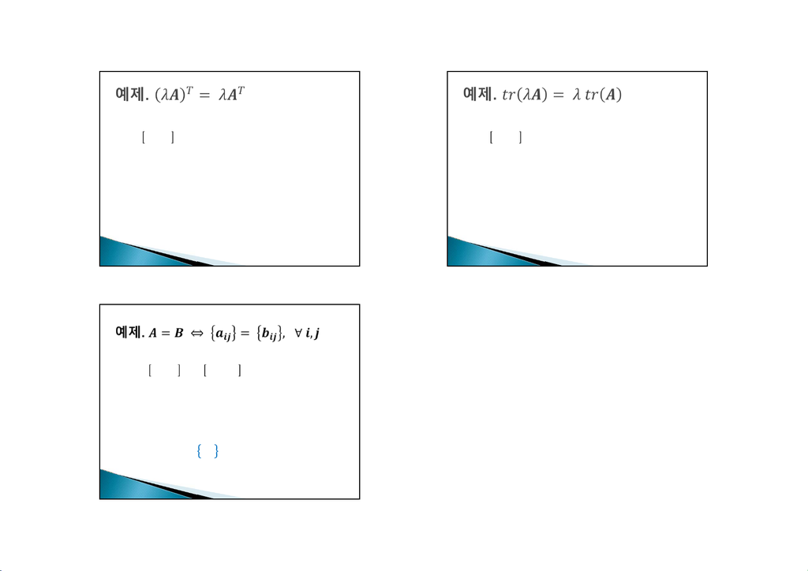

2021-08-11

7

(차원이 같은 행렬에서만 가능한 연산)

343

, 𝝀2일때,

25

행렬대수학 (이영경)

(차원이 같은 행렬에서만 가능한 연산)

343

, 𝝀2일때,

26

행렬대수학 (이영경)

(차원이 같은 행렬에서만 가능한 연산)

343

, 𝑩 101

31 4일때,

27

행렬대수학 (이영경)